# NestpickAnalysis

```python
import pandas as pd
import numpy as np
import seaborn as sns
import matplotlib.pyplot as plt
```

```python
df = pd.read_csv('Nestpick_genZ')
```

Basic investigation of the dataframe

```python
df.head()
```

|  | Rank | City | Country | Government_Digitization | Connectivity | Digital_Banking | Digitized_mobility | Digitized_social_habits | Education | Privacy_and_security | ... | Safety | Protest_Rights | Esports | Concerts | Entreprenerial_Spirit | Co-working_spaces | Affordability | Social_Entrepreneurship | AI_Industry | Total |
| --- | --- | --- | --- | --- | --- | --- | --- | --- | --- | --- | --- | --- | --- | --- | --- | --- | --- | --- | --- | --- | --- |
| 0 | 1 | London | UK | 97.69 | 78.95 | 64.84 | 70.82 | 46.14 | 97.14 | 69.96 | ... | 76.26 | 97.08 | 60.43 | 100.00 | 76.05 | 100.00 | 64.60 | 100.00 | 91.23 | 100.00 |
| 1 | 2 | Stockholm | Sweden | 95.89 | 97.29 | 100.00 | 58.48 | 46.61 | 65.03 | 65.87 | ... | 82.33 | 100.00 | 44.07 | 72.52 | 71.96 | 50.59 | 67.93 | 60.77 | 58.43 | 89.88 |
| 2 | 3 | Los Angeles | USA | 94.13 | 91.05 | 63.06 | 43.38 | 49.58 | 96.87 | 60.10 | ... | 70.91 | 85.66 | 89.39 | 95.36 | 71.76 | 53.16 | 66.52 | 74.33 | 60.45 | 89.40 |
| 3 | 4 | Toronto | Canada | 86.06 | 90.78 | 76.87 | 57.56 | 46.51 | 79.52 | 69.93 | ... | 91.38 | 98.05 | 23.00 | 79.74 | 54.54 | 37.79 | 61.65 | 91.48 | 70.37 | 86.20 |
| 4 | 5 | New York | USA | 94.13 | 86.54 | 63.06 | 56.75 | 49.58 | 84.10 | 60.10 | ... | 64.82 | 85.66 | 31.98 | 96.97 | 72.21 | 98.12 | 48.46 | 91.19 | 88.08 | 86.03 |

5 rows × 26 columns

```python
df.info()
```

```
<class 'pandas.core.frame.DataFrame'>
RangeIndex: 110 entries, 0 to 109
Data columns (total 26 columns):
 #   Column                   Non-Null Count  Dtype
---  ------                   --------------  -----
 0   Rank                     110 non-null    int64
 1   City                     110 non-null    object
 2   Country                  110 non-null    object
 3   Government_Digitization  110 non-null    float64
 4   Connectivity             110 non-null    float64
 5   Digital_Banking          110 non-null    float64
 6   Digitized_mobility       110 non-null    float64
 7   Digitized_social_habits  110 non-null    float64
 8   Education                110 non-null    float64
 9   Privacy_and_security     110 non-null    float64
```

[output cut: 18 more lines]

## Question one: How many times do certain countries occur in the dataset?

```python
countries = df.groupby('Country').mean()
countries
```

| Country | Rank | Government_Digitization | Connectivity | Digital_Banking | Digitized_mobility | Digitized_social_habits | Education | Privacy_and_security | Internationalism | Gender_Equality | ... | Safety | Protest_Rights | Esports | Concerts | Entreprenerial_Spirit | Co-working_spaces | Affordability | Social_Entrepreneurship | AI_Industry | Total |
| --- | --- | --- | --- | --- | --- | --- | --- | --- | --- | --- | --- | --- | --- | --- | --- | --- | --- | --- | --- | --- | --- |
| Argentina | 82.000000 | 70.81 | 23.140000 | 16.53 | 19.280000 | 54.62 | 3.730000 | 69.5600 | 36.350000 | 58.760000 | ... | 33.130000 | 82.74 | 1.950000 | 66.950000 | 21.950000 | 27.210000 | 92.260000 | 48.280000 | 27.830000 | 48.620000 |
| Australia | 31.500000 | 98.52 | 85.522500 | 58.25 | 34.320000 | 54.62 | 60.505000 | 49.0925 | 67.207500 | 57.550000 | ... | 76.322500 | 95.99 | 5.527500 | 69.937500 | 43.257500 | 40.377500 | 69.442500 | 51.530000 | 36.150000 | 74.867500 |
| Austria | 36.000000 | 86.75 | 77.710000 | 47.20 | 55.910000 | 37.88 | 53.730000 | 71.7400 | 60.230000 | 46.680000 | ... | 83.760000 | 99.03 | 4.590000 | 76.880000 | 46.790000 | 60.180000 | 73.800000 | 51.410000 | 31.460000 | 74.130000 |
| Bahrain | 105.000000 | 83.77 | 50.550000 | 18.29 | 5.830000 | 87.67 | 2.670000 | 30.6700 | 89.850000 | 9.890000 | ... | 20.050000 | 11.44 | 2.600000 | 21.750000 | 6.340000 | 10.250000 | 80.750000 | 10.640000 | 10.000000 | 17.210000 |
| Belgium | 50.666667 | 83.19 | 89.140000 | 52.22 | 50.400000 | 46.29 | 37.903333 | 71.6600 | 53.180000 | 54.770000 | ... | 67.356667 | 98.05 | 3.766667 | 62.150000 | 44.980000 | 21.650000 | 70.433333 | 26.583333 | 16.026667 | 64.996667 |
| Brazil | 86.500000 | 70.68 | 35.605000 | 19.50 | 28.565000 | 41.59 | 32.545000 | 28.1100 | 10.065000 | 37.740000 | ... | 24.650000 | 60.99 | 8.230000 | 66.385000 | 12.870000 | 26.630000 | 89.005000 | 27.005000 | 22.770000 | 38.490000 |
| Canada | 25.000000 | 86.06 | 90.148000 | 76.87 | 48.556000 | 46.51 | 59.660000 | 69.9300 | 52.760000 | 74.130000 | ... | 82.164000 | 98.05 | 12.400000 | 71.932000 | 57.318000 | 29.018000 | 71.050000 | 69.744000 | 43.536000 | 77.428000 |
| Chile | 79.000000 | 71.07 | 30.900000 | 21.26 | 32.060000 | 67.16 | 50.590000 | 33.7800 | 47.640000 | 46.280000 | ... | 39.710000 | 91.99 | 3.110000 | 57.580000 | 17.690000 | 23.720000 | 85.030000 | 43.560000 | 22.870000 | 50.710000 |
| China | 93.000000 | 61.73 | 30.545000 | 21.82 | 68.000000 | 45.15 | 46.700000 | 1.0000 | 11.210000 | 34.510000 | ... | 63.390000 | 1.00 | 39.710000 | 66.320000 | 62.685000 | 28.475000 | 86.940000 | 51.710000 | 60.890000 | 28.350000 |
| Colombia | 94.500000 | 62.78 | 24.175000 | 4.93 | 23.420000 | 45.46 | 17.135000 | 36.9700 | 7.185000 | 51.130000 | ... | 17.200000 | 38.11 | 1.215000 | 43.790000 | 9.495000 | 28.990000 | 97.270000 | 29.580000 | 13.700000 | 28.135000 |
| Czechia | 68.500000 | 66.50 | 79.240000 | 36.70 | 42.575000 | 32.74 | 29.060000 | 90.7300 | 33.950000 | 36.580000 | ... | 77.445000 | 98.05 | 2.555000 | 63.210000 | 52.100000 | 22.125000 | 87.600000 | 28.005000 | 24.965000 | 58.085000 |
| Denmark | 13.000000 | 100.00 | 95.000000 | 64.00 | 61.500000 | 53.66 | 54.760000 | 83.7600 | 37.320000 | 70.940000 | ... | 76.880000 | 100.00 | 29.760000 | 76.140000 | 61.100000 | 28.580000 | 60.140000 | 56.280000 | 48.430000 | 80.700000 |
| Estonia | 62.000000 | 89.69 | 89.320000 | 32.73 | 33.780000 | 38.42 | 26.340000 | 90.0800 | 46.680000 | 53.150000 | ... | 57.290000 | 96.10 | 2.050000 | 57.740000 | 60.310000 | 43.330000 | 83.890000 | 43.280000 | 37.670000 | 61.070000 |
| Finland | 14.000000 | 94.85 | 88.630000 | 63.44 | 52.970000 | 43.84 | 53.750000 | 83.9800 | 37.890000 | 94.340000 | ... | 73.740000 | 98.05 | 24.190000 | 70.600000 | 65.500000 | 17.410000 | 69.930000 | 55.750000 | 56.100000 | 80.330000 |
| France | 48.800000 | 94.46 | 86.412000 | 46.44 | 63.372000 | 39.90 | 43.308000 | 85.1600 | 49.002000 | 77.360000 | ... | 53.762000 | 87.83 | 16.248000 | 64.790000 | 51.796000 | 20.984000 | 67.668000 | 31.440000 | 25.120000 | 67.120000 |
| Germany | 19.000000 | 94.07 | 78.111667 | 55.77 | 61.033333 | 34.53 | 49.710000 | 81.7200 | 53.228333 | 76.150000 | ... | 72.765000 | 98.05 | 18.620000 | 82.236667 | 63.935000 | 39.081667 | 73.481667 | 43.430000 | 38.945000 | 79.300000 |
| Greece | 78.000000 | 79.15 | 65.490000 | 17.62 | 37.380000 | 34.27 | 20.240000 | 100.0000 | 51.840000 | 37.790000 | ... | 34.700000 | 91.99 | 1.280000 | 49.190000 | 32.060000 | 12.810000 | 80.140000 | 30.220000 | 19.400000 | 50.720000 |
| Hungary | 81.000000 | 69.62 | 82.840000 | 32.10 | 54.810000 | 38.24 | 24.180000 | 84.3700 | 25.900000 | 34.910000 | ... | 61.550000 | 77.38 | 19.940000 | 54.520000 | 44.970000 | 19.570000 | 89.290000 | 45.420000 | 40.010000 | 49.650000 |
| India | 106.000000 | 40.63 | 43.210000 | 5.83 | 30.810000 | 4.61 | 34.780000 | 30.3600 | 28.170000 | 25.260000 | ... | 53.800000 | 69.26 | 1.710000 | 44.190000 | 24.740000 | 80.720000 | 100.000000 | 62.040000 | 34.080000 | 15.380000 |
| Indonesia | 107.000000 | 32.52 | 36.270000 | 1.44 | 15.170000 | 28.88 | 29.710000 | 6.5600 | 5.880000 | 35.770000 | ... | 10.020000 | 46.49 | 2.920000 | 42.500000 | 20.740000 | 43.130000 | 90.740000 | 47.080000 | 30.510000 | 11.110000 |
| Ireland | 39.000000 | 86.52 | 71.140000 | 50.82 | 65.640000 | 44.87 | 48.370000 | 70.4800 | 48.940000 | 78.220000 | ... | 60.660000 | 98.05 | 6.610000 | 73.160000 | 63.640000 | 33.810000 | 66.610000 | 50.250000 | 48.430000 | 72.670000 |
| Israel | 68.500000 | 81.85 | 48.960000 | 41.40 | 47.755000 | 59.07 | 41.210000 | 71.4400 | 61.415000 | 48.300000 | ... | 64.425000 | 60.99 | 2.530000 | 48.720000 | 65.520000 | 17.145000 | 66.645000 | 54.220000 | 57.015000 | 58.060000 |
| Italy | 73.400000 | 85.27 | 72.064000 | 29.57 | 51.452000 | 38.51 | 46.538000 | 79.6900 | 39.290000 | 47.850000 | ... | 53.152000 | 95.99 | 3.300000 | 54.666000 | 42.038000 | 18.164000 | 71.664000 | 22.974000 | 17.244000 | 54.938000 |
| Japan | 59.500000 | 94.35 | 82.915000 | 48.42 | 55.490000 | 42.61 | 63.805000 | 69.5100 | 17.570000 | 30.060000 | ... | 91.535000 | 98.05 | 30.290000 | 94.550000 | 46.355000 | 25.240000 | 59.275000 | 29.645000 | 44.700000 | 63.395000 |
| Malaysia | 95.000000 | 68.06 | 68.520000 | 26.07 | 43.300000 | 52.92 | 48.530000 | 35.7300 | 37.520000 | 35.720000 | ... | 64.920000 | 40.17 | 7.320000 | 27.810000 | 39.450000 | 66.310000 | 90.150000 | 39.480000 | 25.590000 | 27.900000 |
| Mexico | 92.500000 | 61.85 | 40.835000 | 10.38 | 16.245000 | 44.35 | 27.380000 | 29.0400 | 3.950000 | 47.900000 | ... | 26.235000 | 42.38 | 2.280000 | 61.680000 | 25.475000 | 30.945000 | 93.270000 | 31.155000 | 26.045000 | 30.770000 |
| Morocco | 109.000000 | 31.64 | 40.380000 | 8.79 | 17.390000 | 16.13 | 17.590000 | 19.8300 | 2.420000 | 1.810000 | ... | 18.570000 | 32.00 | 1.160000 | 12.810000 | 13.460000 | 7.250000 | 93.480000 | 10.640000 | 8.130000 | 5.810000 |
| Netherlands | 26.000000 | 93.94 | 94.040000 | 63.22 | 54.120000 | 48.37 | 45.370000 | 83.9800 | 48.706667 | 58.410000 | ... | 76.366667 | 98.05 | 11.390000 | 72.126667 | 79.793333 | 57.450000 | 69.063333 | 40.453333 | 33.833333 | 77.123333 |
| New Zealand | 40.000000 | 94.71 | 83.865000 | 98.64 | 49.345000 | 52.01 | 37.910000 | 64.6900 | 66.380000 | 80.240000 | ... | 80.120000 | 100.00 | 7.205000 | 50.675000 | 41.870000 | 22.680000 | 69.435000 | 40.820000 | 27.700000 | 72.650000 |
| Nigeria | 110.000000 | 1.00 | 1.000000 | 1.00 | 23.910000 | 1.00 | 2.200000 | 15.8100 | 67.870000 | 7.470000 | ... | 11.210000 | 36.31 | 1.000000 | 6.230000 | 1.000000 | 27.740000 | 94.430000 | 31.600000 | 28.950000 | 1.000000 |
| Norway | 48.500000 | 90.81 | 95.450000 | 59.70 | 55.630000 | 49.86 | 24.860000 | 69.5100 | 44.300000 | 100.000000 | ... | 74.310000 | 100.00 | 11.815000 | 67.580000 | 44.555000 | 25.210000 | 46.085000 | 34.140000 | 28.040000 | 69.025000 |
| Oman | 108.000000 | 62.34 | 40.520000 | 24.02 | 14.640000 | 31.17 | 1.000000 | 4.6900 | 58.630000 | 1.000000 | ... | 35.040000 | 17.51 | 1.470000 | 12.810000 | 1.490000 | 2.950000 | 85.450000 | 1.000000 | 1.000000 | 10.430000 |
| Peru | 102.000000 | 55.46 | 22.530000 | 8.00 | 31.400000 | 52.89 | 4.500000 | 34.7300 | 1.000000 | 47.490000 | ... | 14.130000 | 56.94 | 1.610000 | 44.190000 | 6.180000 | 21.210000 | 90.500000 | 26.790000 | 18.820000 | 19.710000 |
| Philippines | 101.000000 | 56.39 | 36.650000 | 10.82 | 28.640000 | 40.88 | 22.250000 | 26.5800 | 2.580000 | 79.430000 | ... | 36.710000 | 48.59 | 6.800000 | 42.500000 | 27.150000 | 55.640000 | 91.770000 | 28.770000 | 11.450000 | 20.600000 |
| Poland | 83.500000 | 80.68 | 75.815000 | 34.83 | 42.110000 | 28.48 | 24.475000 | 74.8700 | 10.710000 | 50.730000 | ... | 72.045000 | 77.49 | 6.925000 | 55.115000 | 34.345000 | 47.885000 | 91.175000 | 35.510000 | 33.655000 | 42.415000 |
| Portugal | 65.500000 | 82.39 | 75.585000 | 34.11 | 39.885000 | 43.18 | 33.650000 | 74.3300 | 29.325000 | 52.340000 | ... | 70.965000 | 100.00 | 10.340000 | 50.675000 | 40.995000 | 47.120000 | 84.335000 | 22.255000 | 19.895000 | 59.280000 |
| Qatar | 99.000000 | 67.33 | 62.630000 | 24.32 | 1.000000 | 100.00 | 41.230000 | 33.7800 | 88.010000 | 10.700000 | ... | 77.570000 | 15.30 | 2.480000 | 1.000000 | 11.650000 | 7.460000 | 78.190000 | 20.270000 | 1.000000 | 24.330000 |
| Romania | 86.000000 | 59.24 | 83.350000 | 20.32 | 32.790000 | 32.20 | 3.600000 | 89.9400 | 10.490000 | 43.850000 | ... | 56.390000 | 83.71 | 36.890000 | 43.730000 | 30.550000 | 33.610000 | 92.320000 | 18.370000 | 23.840000 | 37.180000 |
| Russia | 97.000000 | 81.38 | 57.970000 | 17.94 | 32.130000 | 27.66 | 55.035000 | 26.4300 | 31.960000 | 39.810000 | ... | 21.180000 | 11.22 | 22.595000 | 52.910000 | 22.875000 | 10.715000 | 89.915000 | 36.610000 | 30.290000 | 25.925000 |
| Singapore | 74.000000 | 94.80 | 100.000000 | 44.25 | 63.670000 | 60.91 | 88.780000 | 43.4600 | 57.140000 | 48.250000 | ... | 100.000000 | 33.80 | 41.820000 | 53.020000 | 58.630000 | 61.550000 | 65.580000 | 70.260000 | 67.560000 | 54.970000 |
| South Africa | 91.000000 | 58.29 | 53.545000 | 21.63 | 17.645000 | 16.12 | 31.565000 | 22.7200 | 18.515000 | 61.640000 | ... | 5.555000 | 81.80 | 1.340000 | 52.025000 | 17.990000 | 17.095000 | 88.285000 | 30.570000 | 29.225000 | 29.850000 |
| South Korea | 66.000000 | 97.86 | 99.140000 | 98.65 | 52.080000 | 65.19 | 85.540000 | 28.1600 | 18.080000 | 22.020000 | ... | 75.800000 | 83.71 | 100.000000 | 52.790000 | 54.230000 | 20.140000 | 62.240000 | 59.450000 | 60.940000 | 59.160000 |
| Spain | 30.000000 | 88.56 | 88.660000 | 48.49 | 55.085000 | 39.77 | 46.230000 | 89.7600 | 49.660000 | 64.020000 | ... | 76.065000 | 85.66 | 5.835000 | 71.660000 | 47.295000 | 59.630000 | 80.085000 | 49.360000 | 52.315000 | 76.135000 |
| Sweden | 12.000000 | 95.89 | 94.410000 | 100.00 | 39.760000 | 46.61 | 51.140000 | 65.8700 | 54.820000 | 94.740000 | ... | 68.106667 | 100.00 | 32.470000 | 62.560000 | 69.426667 | 38.583333 | 71.476667 | 46.660000 | 42.106667 | 82.766667 |
| Switzerland | 51.000000 | 90.23 | 96.593333 | 44.45 | 58.100000 | 40.58 | 49.490000 | 77.2300 | 69.613333 | 67.660000 | ... | 78.243333 | 100.00 | 13.316667 | 65.313333 | 85.200000 | 35.510000 | 15.246667 | 48.380000 | 28.953333 | 66.890000 |
| Thailand | 103.000000 | 56.95 | 65.110000 | 8.52 | 33.290000 | 52.36 | 28.420000 | 24.7900 | 5.820000 | 40.220000 | ... | 13.950000 | 19.61 | 13.600000 | 52.550000 | 27.540000 | 40.050000 | 81.840000 | 35.570000 | 17.140000 | 19.500000 |
| Turkey | 104.000000 | 66.99 | 44.450000 | 20.53 | 33.270000 | 40.48 | 41.200000 | 30.3600 | 7.850000 | 10.300000 | ... | 26.660000 | 7.22 | 4.580000 | 54.000000 | 34.260000 | 22.980000 | 92.950000 | 23.400000 | 39.530000 | 18.220000 |
| UK | 20.400000 | 97.69 | 78.036000 | 64.84 | 49.542000 | 46.14 | 67.414000 | 69.9600 | 50.104000 | 75.340000 | ... | 63.832000 | 97.08 | 16.028000 | 82.838000 | 72.134000 | 45.764000 | 73.026000 | 63.126000 | 39.732000 | 81.618000 |
| USA | 34.733333 | 94.13 | 84.550667 | 63.06 | 43.870000 | 49.58 | 59.024000 | 60.1000 | 49.925333 | 55.814667 | ... | 57.026000 | 85.66 | 23.157333 | 85.210667 | 73.142000 | 37.594000 | 65.764000 | 68.324667 | 54.582667 | 73.912000 |
| United Arab Emirates | 91.000000 | 86.65 | 72.160000 | 26.89 | 37.790000 | 73.71 | 2.080000 | 27.2600 | 100.000000 | 15.960000 | ... | 66.800000 | 11.07 | 6.540000 | 38.620000 | 35.530000 | 53.000000 | 73.860000 | 40.500000 | 45.090000 | 30.320000 |

50 rows × 24 columns

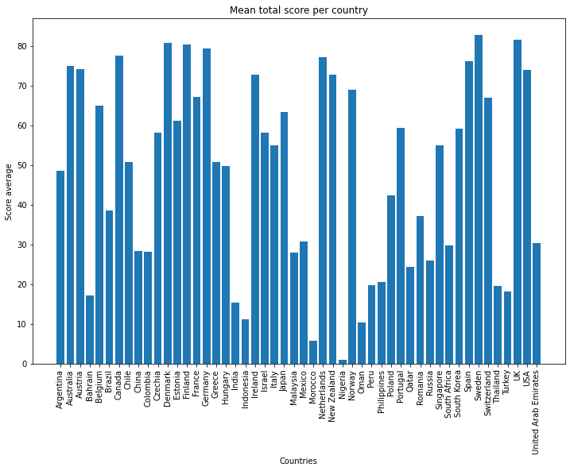

```python
plt.figure(figsize=(12,8))
plt.bar(countries.index, countries.Total)
plt.title('Mean total score per country')
plt.xlabel('Countries')
plt.ylabel('Score average')
plt.xticks(rotation=90);
```

```python
df['Country'].value_counts()
```

```
USA                     15
Germany                  6
Italy                    5
France                   5
Canada                   5
UK                       5
Australia                4
Sweden                   3
Netherlands              3
Belgium                  3
Switzerland              3
New Zealand              2
Japan                    2
Colombia                 2
Mexico                   2
Czechia                  2
Russia                   2
Israel                   2
South Africa             2
Portugal                 2
Spain                    2
Norway                   2
Brazil                   2
China                    2
Poland                   2
United Arab Emirates     1
Nigeria                  1
Turkey                   1
Philippines              1
Morocco                  1
Bahrain                  1
Qatar                    1
South Korea              1
Argentina                1
Chile                    1
Singapore                1
Austria                  1
Hungary                  1
Oman                     1
Denmark                  1
Greece                   1
Estonia                  1
Peru                     1
Thailand                 1
Malaysia                 1
Indonesia                1
India                    1
Ireland                  1
Romania                  1
Finland                  1
Name: Country, dtype: int64
```

The ten countries that occur the most are the USA, Germany, the UK, Italy, Canada, France, Australia, Belgium, Switzerland, Sweden and the Netherlands. These are mostly located in Northern America and Europe, with Australia being in Oceania.

## Question two: Where are the most affordable countries located?

```python
afford_cit = df[['City', 'Country', 'Rank', 'Affordability']]
afford_cit.head(1)
```

|  | City | Country | Rank | Affordability |
| --- | --- | --- | --- | --- |
| 0 | London | UK | 1 | 64.6 |

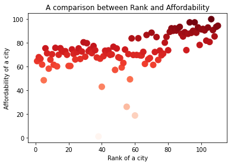

```python
plt.scatter(afford_cit['Rank'], afford_cit['Affordability'], c=afford_cit['Affordability'], cmap=plt.get_cmap('Reds'), s=100)
plt.title('A comparison between Rank and Affordability')
plt.xlabel('Rank of a city')
plt.ylabel('Affordability of a city');
```

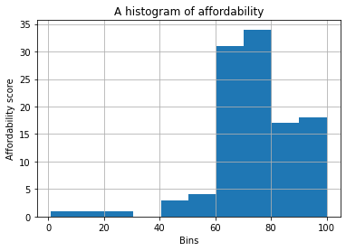

```python
df['Affordability'].hist()
plt.title('A histogram of affordability')
plt.xlabel('Bins')
plt.ylabel('Affordability score');
```

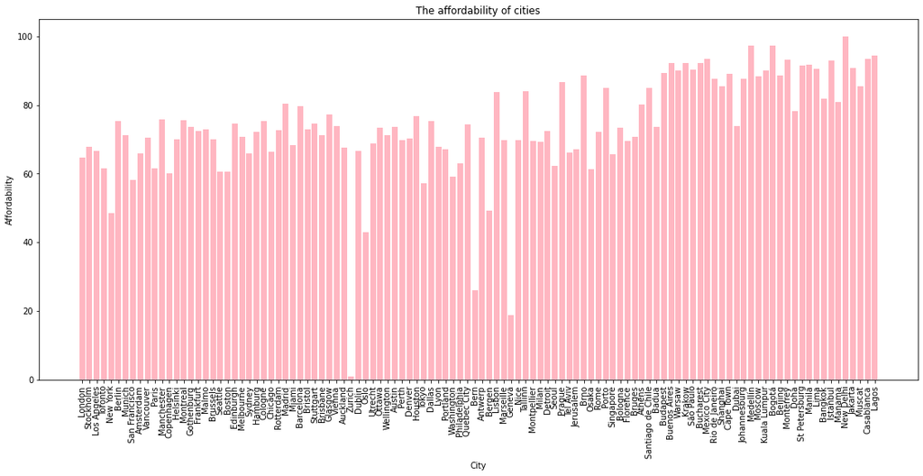

```python
plt.figure(figsize=(19,8))
plt.bar(afford_cit['City'], afford_cit['Affordability'], color=['#FFB6C1'])
plt.title('The affordability of cities')
plt.xlabel('City')
plt.ylabel('Affordability')
plt.xticks(rotation = 90);
```

The higher the bar, the more affordable the country is to live in. Therefore, Zurich which has the lowest bar, is the least affordable city to live in, while New Delhi which has the highest bar is the most affordable city to live in.

Which countries are the most expensive to live in and which are the cheapest?

```python
low_cit = afford_cit.query('Affordability > 90.0')
exp_cit = afford_cit.query('Affordability < 50.0')
```

```python
exp_cit
```

|  | City | Country | Rank | Affordability |
| --- | --- | --- | --- | --- |
| 4 | New York | USA | 5 | 48.46 |
| 37 | Zurich | Switzerland | 38 | 1.00 |
| 39 | Oslo | Norway | 40 | 42.94 |
| 54 | Bern | Switzerland | 55 | 26.04 |
| 56 | Bergen | Norway | 57 | 49.23 |
| 59 | Geneva | Switzerland | 60 | 18.70 |

Switzerland has the three least affordable cities to live in, with Norway featuring two cities and New York city in the USA, also being very unaffordable to live in.

```python
low_cit
```

|  | City | Country | Rank | Affordability |
| --- | --- | --- | --- | --- |
| 81 | Buenos Aires | Argentina | 82 | 92.26 |
| 82 | Warsaw | Poland | 83 | 90.13 |
| 83 | Krakow | Poland | 84 | 92.22 |
| 84 | São Paulo | Brazil | 85 | 90.36 |
| 85 | Bucharest | Romania | 86 | 92.32 |
| 86 | Mexico City | Mexico | 87 | 93.48 |
| 92 | Medellín | Colombia | 93 | 97.27 |
| 94 | Kuala Lumpur | Malaysia | 95 | 90.15 |
| 95 | Bogotá | Colombia | 96 | 97.27 |
| 97 | Monterrey | Mexico | 98 | 93.06 |
| 99 | St Petersburg | Russia | 100 | 91.41 |
| 100 | Manila | Philippines | 101 | 91.77 |
| 101 | Lima | Peru | 102 | 90.50 |
| 103 | Istanbul | Turkey | 104 | 92.95 |
| 105 | New Delhi | India | 106 | 100.00 |
| 106 | Jakarta | Indonesia | 107 | 90.74 |
| 108 | Casablanca | Morocco | 109 | 93.48 |
| 109 | Lagos | Nigeria | 110 | 94.43 |

## Question three: How do the fifty most desirable countries compare?

```python
top_50 = df.query('Rank <= 50')
top_50.head()
```

|  | Rank | City | Country | Government_Digitization | Connectivity | Digital_Banking | Digitized_mobility | Digitized_social_habits | Education | Privacy_and_security | ... | Safety | Protest_Rights | Esports | Concerts | Entreprenerial_Spirit | Co-working_spaces | Affordability | Social_Entrepreneurship | AI_Industry | Total |
| --- | --- | --- | --- | --- | --- | --- | --- | --- | --- | --- | --- | --- | --- | --- | --- | --- | --- | --- | --- | --- | --- |
| 0 | 1 | London | UK | 97.69 | 78.95 | 64.84 | 70.82 | 46.14 | 97.14 | 69.96 | ... | 76.26 | 97.08 | 60.43 | 100.00 | 76.05 | 100.00 | 64.60 | 100.00 | 91.23 | 100.00 |
| 1 | 2 | Stockholm | Sweden | 95.89 | 97.29 | 100.00 | 58.48 | 46.61 | 65.03 | 65.87 | ... | 82.33 | 100.00 | 44.07 | 72.52 | 71.96 | 50.59 | 67.93 | 60.77 | 58.43 | 89.88 |
| 2 | 3 | Los Angeles | USA | 94.13 | 91.05 | 63.06 | 43.38 | 49.58 | 96.87 | 60.10 | ... | 70.91 | 85.66 | 89.39 | 95.36 | 71.76 | 53.16 | 66.52 | 74.33 | 60.45 | 89.40 |
| 3 | 4 | Toronto | Canada | 86.06 | 90.78 | 76.87 | 57.56 | 46.51 | 79.52 | 69.93 | ... | 91.38 | 98.05 | 23.00 | 79.74 | 54.54 | 37.79 | 61.65 | 91.48 | 70.37 | 86.20 |
| 4 | 5 | New York | USA | 94.13 | 86.54 | 63.06 | 56.75 | 49.58 | 84.10 | 60.10 | ... | 64.82 | 85.66 | 31.98 | 96.97 | 72.21 | 98.12 | 48.46 | 91.19 | 88.08 | 86.03 |

5 rows × 26 columns

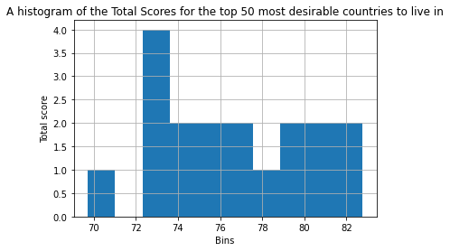

```python
# top fifty grouped by countries
top_50_c = top_50.groupby('Country').mean()
top_50_c['Total'].hist()
plt.title('A histogram of the Total Scores for the top 50 most desirable countries to live in')
plt.xlabel('Bins')
plt.ylabel('Total score');
```

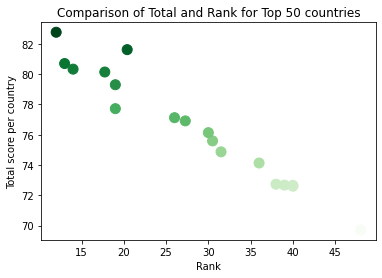

```python
# horizantal barchart showcasing top 50 countries
#plt.rcdefaults()
#fig, ax = plt.subplots()

#plt.figure(figsize=(20,3))


#ax.barh(top_50_c['Total'], top_50_c['Rank'], align='center')
#ax.set_yticks(top_50_c['Total'])
#ax.set_yticklabels(top_50_c.index)
#ax.invert_yaxis()
#ax.set_xlabel('Rank')
#ax.set_title('Comparison of Total and Rank for Top 50 countries')

plt.scatter(top_50_c['Rank'], top_50_c['Total'], c=top_50_c['Total'], cmap=plt.get_cmap('Greens'), s=100)
plt.title('Comparison of Total and Rank for Top 50 countries')
plt.xlabel('Rank')
plt.ylabel('Total score per country')
plt.show();
```

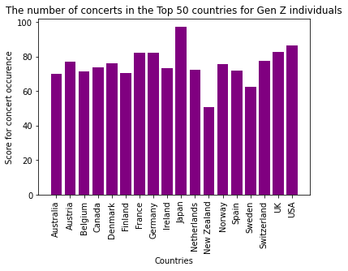

```python
plt.bar(top_50_c.index, top_50_c['Concerts'], align='center', color=['#800080'])
plt.title('The number of concerts in the Top 50 countries for Gen Z individuals')
plt.xlabel('Countries')
plt.ylabel('Score for concert occurence')
plt.xticks(rotation=90);
```

It makes sense that Japan has the highest score for music concerts, due to its prime location and cultural significance, the country receives many artists from K-Pop idols through to American artists. In 2017, approximately 48 million people attended concerts in Japan, representing a constant increase from about 17 million in 2000. (Statista. 2021. Japan: concert attendance | Statista. [online] Available at: https://www.statista.com/statistics/689501/japan-concert-attendance/ [Accessed 17 March 2021].)

```python
# discover the maximum values per category per country
top_50_m = top_50.groupby('Country').max()
top_50_m
```

| Country | Rank | City | Government_Digitization | Connectivity | Digital_Banking | Digitized_mobility | Digitized_social_habits | Education | Privacy_and_security | Internationalism | ... | Safety | Protest_Rights | Esports | Concerts | Entreprenerial_Spirit | Co-working_spaces | Affordability | Social_Entrepreneurship | AI_Industry | Total |
| --- | --- | --- | --- | --- | --- | --- | --- | --- | --- | --- | --- | --- | --- | --- | --- | --- | --- | --- | --- | --- | --- |
| Australia | 45 | Sydney | 98.52 | 88.48 | 58.25 | 48.97 | 54.62 | 71.37 | 53.93 | 70.39 | ... | 83.82 | 95.99 | 9.79 | 75.54 | 47.75 | 56.40 | 71.30 | 65.51 | 50.18 | 77.42 |
| Austria | 36 | Vienna | 86.75 | 77.71 | 47.20 | 55.91 | 37.88 | 53.73 | 71.74 | 60.23 | ... | 83.76 | 99.03 | 4.59 | 76.88 | 46.79 | 60.18 | 73.80 | 51.41 | 31.46 | 74.13 |
| Belgium | 19 | Brussels | 83.19 | 88.77 | 52.22 | 59.31 | 46.29 | 68.28 | 71.66 | 72.23 | ... | 67.61 | 98.05 | 5.48 | 71.61 | 46.71 | 41.65 | 69.93 | 58.99 | 27.26 | 77.72 |
| Canada | 42 | Vancouver | 86.06 | 91.00 | 76.87 | 67.03 | 46.51 | 79.52 | 69.93 | 73.92 | ... | 91.38 | 98.05 | 23.00 | 79.74 | 56.77 | 37.79 | 75.49 | 91.48 | 70.37 | 86.20 |
| Denmark | 13 | Copenhagen | 100.00 | 95.00 | 64.00 | 61.50 | 53.66 | 54.76 | 83.76 | 37.32 | ... | 76.88 | 100.00 | 29.76 | 76.14 | 61.10 | 28.58 | 60.14 | 56.28 | 48.43 | 80.70 |
| Finland | 14 | Helsinki | 94.85 | 88.63 | 63.44 | 52.97 | 43.84 | 53.75 | 83.98 | 37.89 | ... | 73.74 | 98.05 | 24.19 | 70.60 | 65.50 | 17.41 | 69.93 | 55.75 | 56.10 | 80.33 |
| France | 50 | Paris | 94.46 | 87.40 | 46.44 | 100.00 | 39.90 | 75.79 | 85.16 | 51.85 | ... | 57.68 | 87.83 | 38.73 | 92.65 | 56.12 | 39.78 | 67.83 | 66.30 | 73.66 | 82.13 |
| Germany | 33 | Stuttgart | 94.07 | 82.56 | 55.77 | 67.01 | 34.53 | 80.89 | 81.72 | 64.35 | ... | 85.23 | 98.05 | 48.01 | 90.53 | 67.78 | 61.46 | 75.41 | 67.46 | 70.83 | 84.53 |
| Ireland | 39 | Dublin | 86.52 | 71.14 | 50.82 | 65.64 | 44.87 | 48.37 | 70.48 | 48.94 | ... | 60.66 | 98.05 | 6.61 | 73.16 | 63.64 | 33.81 | 66.61 | 50.25 | 48.43 | 72.67 |
| Japan | 48 | Tokyo | 94.35 | 83.09 | 48.42 | 59.29 | 42.61 | 77.65 | 69.51 | 15.98 | ... | 91.51 | 98.05 | 56.25 | 97.26 | 49.90 | 38.33 | 57.15 | 39.84 | 69.59 | 69.71 |
| Netherlands | 41 | Utrecht | 93.94 | 95.27 | 63.22 | 75.21 | 48.37 | 73.25 | 83.98 | 57.22 | ... | 81.05 | 98.05 | 23.58 | 80.30 | 81.23 | 80.17 | 72.65 | 56.12 | 54.90 | 83.02 |
| New Zealand | 43 | Wellington | 94.71 | 84.48 | 98.64 | 59.51 | 52.01 | 45.16 | 64.69 | 70.57 | ... | 93.30 | 100.00 | 11.50 | 56.50 | 43.17 | 24.98 | 71.23 | 44.09 | 34.14 | 74.06 |
| Norway | 40 | Oslo | 90.81 | 95.74 | 59.70 | 70.99 | 49.86 | 25.52 | 69.51 | 52.17 | ... | 70.51 | 100.00 | 18.62 | 75.65 | 46.91 | 34.36 | 42.94 | 45.99 | 39.89 | 72.60 |
| Spain | 31 | Madrid | 88.56 | 90.89 | 48.49 | 56.19 | 39.77 | 51.74 | 89.76 | 51.58 | ... | 76.48 | 85.66 | 6.08 | 72.12 | 49.03 | 64.65 | 80.48 | 51.87 | 54.19 | 76.15 |
| Sweden | 18 | Stockholm | 95.89 | 97.29 | 100.00 | 58.48 | 46.61 | 65.03 | 65.87 | 60.41 | ... | 82.33 | 100.00 | 49.64 | 72.52 | 71.96 | 50.59 | 73.52 | 60.77 | 58.43 | 89.88 |
| Switzerland | 38 | Zurich | 90.23 | 96.60 | 44.45 | 51.34 | 40.58 | 89.11 | 77.23 | 68.75 | ... | 71.72 | 100.00 | 31.57 | 77.37 | 75.79 | 41.73 | 1.00 | 58.87 | 45.59 | 72.73 |
| UK | 35 | Manchester | 97.69 | 79.37 | 64.84 | 70.82 | 46.14 | 97.14 | 69.96 | 64.68 | ... | 76.26 | 97.08 | 60.43 | 100.00 | 76.05 | 100.00 | 77.33 | 100.00 | 91.23 | 100.00 |
| USA | 49 | Seattle | 94.13 | 91.05 | 63.06 | 61.81 | 49.58 | 100.00 | 60.10 | 82.40 | ... | 71.77 | 85.66 | 89.39 | 96.97 | 100.00 | 98.12 | 76.68 | 91.19 | 100.00 | 89.40 |

18 rows × 25 columns

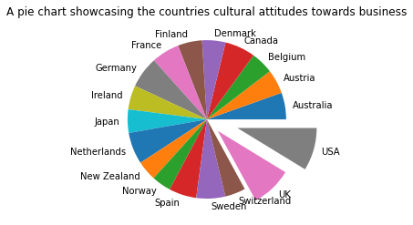

```python
# pie chart showing values of total business columns

#creating total business column
top_50_m['total_bus'] = (top_50_m['Entreprenerial_Spirit'] + top_50_m['Co-working_spaces'] + top_50_m['Affordability'] + top_50_m['Social_Entrepreneurship'] + top_50_m['AI_Industry'])

displace = [0, 0, 0, 0, 0, 0, 0, 0, 0, 0, 0, 0, 0, 0, 0, 0, 0.2, 0.4]
plt.pie(top_50_m['total_bus'], labels=top_50_m.index, explode=displace)
plt.title('A pie chart showcasing the countries cultural attitudes towards business');
```